# Impact of Subgroup Misclassification on Detecting Heterogeneous Treatment Effects in *Staphylococcus aureus* Bacteremia: A Simulation Study

Author

Fergus Hamilton

Published

December 30, 2025

# 1 Abstract

**Background:** *Staphylococcus aureus* bacteremia (SAB) exhibits significant clinical heterogeneity. Recently identified subphenotypes show potential for heterogeneous treatment effects (HTE), but the impact of inevitable patient misclassification on detecting HTE is unclear.

**Conclusions:** Detecting HTE in SAB is challenging. Post-hoc analyses require very large trials and high classification accuracy. Enrichment strategies can reduce NNR but face substantial screening burdens (NNS) heavily influenced by test accuracy and subgroup prevalence. Robust classification methods are crucial for advancing stratified medicine approaches in SAB.

# 2 Introduction

*Staphylococcus aureus* bacteremia (SAB) is a common and serious infection associated with significant morbidity and mortality [@Tong2015]. Globally, *S. aureus* is a leading cause of death due to bacterial pathogens and bacteremia [@GBD2019]. A defining feature of SAB is its clinical heterogeneity, encompassing variations in patient characteristics (e.g., age, comorbidities), pathogen factors (e.g., methicillin resistance), source of infection, and disease severity [@Tong2015]. Despite this heterogeneity, clinical trials in SAB often treat it as a single entity, potentially obscuring differential treatment effects within patient subgroups [@Thwaites2018; Holland2022]. Strategy trials investigating adjunctive or alternative therapies have frequently failed to show overall benefit compared to standard care [@Thwaites2018; Paulsen2024].

Recent efforts have focused on identifying clinically relevant subphenotypes within SAB to enable better patient stratification for research and potentially personalized treatment [@Davis2023]. Swets, Russell, et al. recently used latent class analysis on data from observational and trial cohorts (Edinburgh, ARREST, SAFO) to identify five distinct and reproducible clinical subphenotypes (A-E) based on routinely collected clinical data [@Swets2024]. Crucially, a secondary analysis of the ARREST trial (Adjunctive Rifampicin for *S. aureus* Bacteraemia) suggested potential heterogeneous treatment effects (HTE) of adjunctive rifampicin across these subphenotypes regarding 84-day mortality. Notably, rifampicin appeared potentially harmful in subphenotype B (Nosocomial IV catheter-associated SAB; OR 18.8) and potentially beneficial in subphenotype E (SAB associated with injecting drug use; OR 0.3) [@Swets2024].

The possibility of such HTE raises critical questions for future clinical trial design and the implementation of stratified medicine approaches. If treatment effects truly differ between subgroups, accurately identifying these subgroups becomes paramount. However, any diagnostic test or classification algorithm used to assign patients to subphenotypes will inevitably have imperfect accuracy [@Siontis2014]. Misclassifying patients can lead to biased estimates of subgroup-specific effects, reduced statistical power to detect true HTE, and potentially misleading conclusions about which patients benefit or are harmed by a treatment [@Kent2018; Sussman2017]. Understanding the quantitative impact of misclassification is essential for interpreting subgroup analyses and designing efficient trials, including potential enrichment strategies [@Anthenelli2011; Simon2004].

We structure the reporting of our simulation methods and results following the ADEMP framework [@Morris2019].

# 3 Methods

This simulation study was designed and reported following the ADEMP framework [@Morris2019; Siepe2024].

## 3.2 Data-Generating Mechanisms (DGMs)

We simulated individual patient data for two-arm (control vs. treatment) RCTs. The core DGM involved the following steps for each simulated patient:

1. **True Subgroup Assignment:** Each patient was assigned a ‘true’ subgroup (A, B, C, D, or E) based on sampling from a multinomial distribution defined by the population prevalence (`freq_vector`).
2. **Treatment Assignment:** Patients were assigned to treatment (1) or control (0) with equal probability (0.5).
3. **Outcome Generation:** A binary outcome (‘success’, representing death by 84 days = 1, survival = 0) was generated based on the patient’s true subgroup, treatment assignment, the subgroup-specific baseline event probability (`p0_vector`, defined using overall mortality across both trial arms), and the subgroup-specific treatment effect (odds ratio, `or_vector`). The probability of death for patient `i` in subgroup `j` receiving treatment `t` (0 or 1) was calculated using the logistic model: $P(\text{Death}_{ij} | \text{Treatment}=t) = \text{expit}(\text{logit}(p0_j) + \log(OR_j) \times t)$. The outcome was then drawn from a Bernoulli distribution with this probability.

**Misclassification / Testing Mechanism:** * For Aims 2 and 3, patient classification accuracy was simulated using the `misclassify_group` function. For each patient with true subgroup `j`, the assigned subgroup was set to `j` with probability `accuracy`. With probability `1 - accuracy`, the assigned subgroup was randomly sampled from the overall population distribution (`freq_vector`). This simulates a classification process where errors result in assignment proportional to overall prevalence.

## 3.3 Estimands

The target quantities (estimands) for each aim were:

- **Aim 1:** The statistical power to reject the null hypothesis of no treatment effect (OR=1) within each subgroup (A-E) in a post-hoc analysis, using a Bonferroni-corrected alpha level (0.05 / 5 = 0.01).
- **Aim 2:**
  - Primary: Statistical power (as in Aim 1, plus overall power at alpha=0.05).
  - Secondary: Bias (mean difference between estimated log(OR) and true log(OR)), Mean Squared Error (MSE) of the log(OR) estimate, and Wrong Direction Rate (percentage of estimates where sign(log(OR)) differs from sign(true log(OR))).
  - The true marginal treatment effect for the “Overall” analysis was determined by fitting a logistic regression model to the entire simulated dataset for each replicate, as the odds ratio is a non-collapsible effect measure.
- **Aim 3:**
  - Primary: Number Needed to Screen (NNS) to achieve 80% power (alpha=0.05) in an enrichment trial for a target subgroup.
  - Secondary: Average Number Needed to Randomize (NNR) within the enriched cohort corresponding to the NNS achieving 80% power.

## 3.5 Performance Measures

The following performance measures were calculated by aggregating results across the `n_reps_global` replicates for each scenario:

- **Power:** Mean indicator of (p-value < alpha). Alpha was 0.01 (Bonferroni) for Aims 1 & 2 subgroup analyses, 0.05 for Aim 2 overall analysis, and 0.05 for Aim 3 enrichment analysis.
- **Bias:** Mean (estimated log(OR) - true target log(OR)).
- **MSE:** Mean ((estimated log(OR) - true target log(OR))^2).
- **Wrong Direction Rate (%):** Mean indicator of (sign(estimated log(OR)) != sign(true target log(OR))) * 100. (Calculated only for subgroups with true OR != 1).
- **NNS (Aim 3):** Smallest `n_screened` achieving mean power >= 0.8.
- **NNR (Aim 3):** Mean `n_randomized_actual` corresponding to the NNS achieving 80% power.

# 4 Results

### 4.0.1 Aim 1: Sample Size Requirements (Post-Hoc Analysis Power)

Aim 1: Power for Post-Hoc Subgroup Analysis vs. Total Trial Size (ARREST Shrunk ORs, Perfect Classification)

| scenario_name | Total Sample Size | scenario_set | B | C | D | E |
| --- | --- | --- | --- | --- | --- | --- |
| ARREST_shrunk | 500 | main | 26% | 1% | 1% | 0% |
| ARREST_shrunk | 1000 | main | 67% | 2% | 2% | 0% |
| ARREST_shrunk | 2000 | main | 96% | 2% | 2% | 2% |
| ARREST_shrunk | 3000 | main | 99% | 3% | 3% | 4% |
| ARREST_shrunk | 5000 | main | 100% | 6% | 5% | 10% |
| ARREST_shrunk | 7500 | main | 100% | 10% | 8% | 16% |
| ARREST_shrunk | 10000 | main | 100% | 13% | 11% | 23% |
| ARREST_shrunk | 15000 | main | 100% | 20% | 17% | 36% |
| ARREST_shrunk | 20000 | main | 100% | 28% | 25% | 53% |

Power calculated at Bonferroni-corrected alpha = 0.01

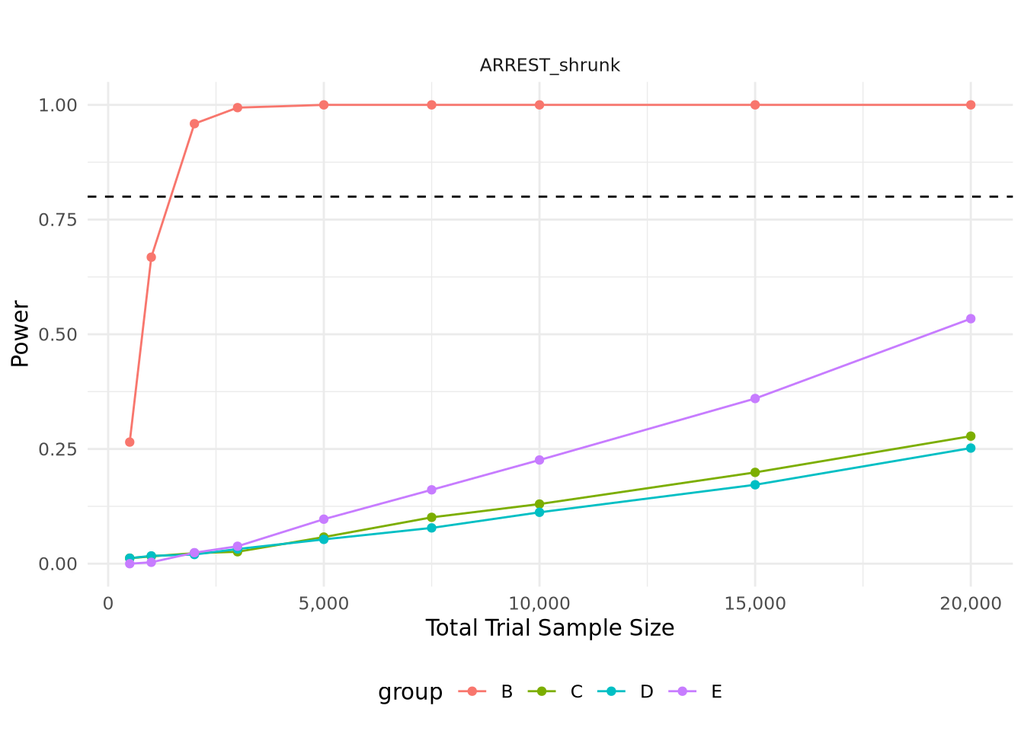

### 4.0.2 Aim 2: Impact of Classification Accuracy (Post-Hoc Analysis)

Aim 2: Post-Hoc Analysis Summary vs. Accuracy (ARREST Shrunk ORs, Total N = 10,000)

**ARREST (Shrunk) Scenario**

| Accuracy | B Power | B Bias | B MSE | B Wrong Dir % | C Power | C Bias | C MSE | C Wrong Dir % | D Power | D Bias | D MSE | D Wrong Dir % | E Power | E Bias | E MSE | E Wrong Dir % |
| --- | --- | --- | --- | --- | --- | --- | --- | --- | --- | --- | --- | --- | --- | --- | --- | --- |
| 0.70 | 100.0% | −0.43 | 0.21 | 0.0% | 1.7% | 0.07 | 0.01 | 31.1% | 10.6% | 0.00 | 0.02 | 10.5% | 1.2% | 0.56 | 0.35 | 41.0% |
| 0.80 | 100.0% | −0.29 | 0.11 | 0.0% | 3.9% | 0.05 | 0.01 | 20.8% | 10.0% | 0.00 | 0.02 | 9.8% | 2.5% | 0.47 | 0.27 | 28.3% |
| 0.90 | 100.0% | −0.15 | 0.05 | 0.0% | 8.4% | 0.02 | 0.01 | 13.8% | 9.6% | 0.00 | 0.02 | 8.6% | 7.2% | 0.33 | 0.17 | 14.6% |
| 0.95 | 100.0% | −0.08 | 0.03 | 0.0% | 10.4% | 0.01 | 0.01 | 9.1% | 10.8% | 0.00 | 0.02 | 9.0% | 12.9% | 0.20 | 0.13 | 7.2% |
| 0.99 | 100.0% | −0.02 | 0.03 | 0.0% | 12.2% | 0.00 | 0.01 | 7.0% | 11.6% | 0.00 | 0.02 | 9.1% | 19.9% | 0.06 | 0.10 | 3.8% |
| 1.00 | 100.0% | 0.00 | 0.03 | 0.0% | 13.0% | 0.00 | 0.01 | 6.8% | 11.2% | 0.00 | 0.02 | 9.1% | 22.6% | 0.00 | 0.11 | 2.8% |

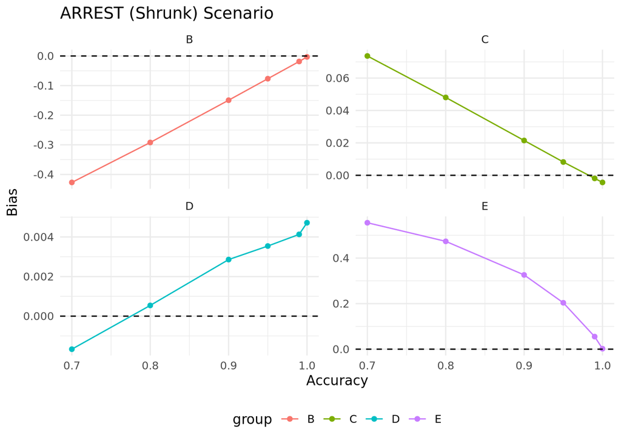

[figure not shown]

### 4.0.3 Aim 3: Sample Size Requirements (Enrichment Trial, Closed-Form)

Aim 3: Closed-Form NNS/NNR by Test Type and Target Group

| Test Type | Group | NNS | NNR | Predicted β | Bias |
| --- | --- | --- | --- | --- | --- |
| Balanced/Moderate | B | 3,079 | 877 | 0.526 | −0.941 |
| High Sens/High Spec | B | 1,346 | 239 | 1.064 | −0.403 |
| High Sens/Low Spec | B | 3,058 | 1,198 | 0.448 | −1.019 |
| Low Sens/High Spec | B | 1,972 | 280 | 0.970 | −0.497 |
| Near-Perfect | B | 1,074 | 160 | 1.366 | −0.101 |
| Perfect (100%) | B | 1,017 | 144 | 1.467 | 0.000 |
| Balanced/Moderate | C | 9,117,554 | 3,815,420 | 0.008 | 0.125 |
| High Sens/High Spec | C | 79,227 | 29,925 | −0.084 | 0.033 |
| High Sens/Low Spec | C | 454,851 | 244,108 | 0.030 | 0.148 |
| Low Sens/High Spec | C | 137,977 | 39,555 | −0.074 | 0.044 |
| Near-Perfect | C | 46,601 | 17,095 | −0.111 | 0.007 |
| Perfect (100%) | C | 41,558 | 15,132 | −0.118 | 0.000 |
| Balanced/Moderate | D | 28,172 | 8,333 | 0.164 | −0.005 |
| High Sens/High Spec | D | 38,874 | 7,529 | 0.166 | −0.002 |
| High Sens/Low Spec | D | 20,989 | 8,475 | 0.163 | −0.005 |
| Low Sens/High Spec | D | 49,744 | 7,649 | 0.166 | −0.002 |
| Near-Perfect | D | 43,202 | 7,191 | 0.168 | 0.000 |
| Perfect (100%) | D | 44,433 | 7,093 | 0.168 | 0.000 |
| Balanced/Moderate | E | 114,012 | 35,347 | 0.095 | 0.697 |
| High Sens/High Spec | E | 320,510 | 68,923 | −0.094 | 0.507 |
| High Sens/Low Spec | E | 57,182 | 23,971 | 0.112 | 0.714 |
| Low Sens/High Spec | E | 1,534,444 | 259,621 | −0.045 | 0.557 |
| Near-Perfect | E | 39,688 | 7,530 | −0.388 | 0.214 |
| Perfect (100%) | E | 23,484 | 4,307 | −0.602 | 0.000 |

# 5 Discussion

## 5.2 Appendix: Aim 3 Simulation Validation

Aim 3: Simulation vs Closed-Form Validation (Supplementary)

Aim 3: NNS, NNR, and Performance Metrics by Method

[output not shown]

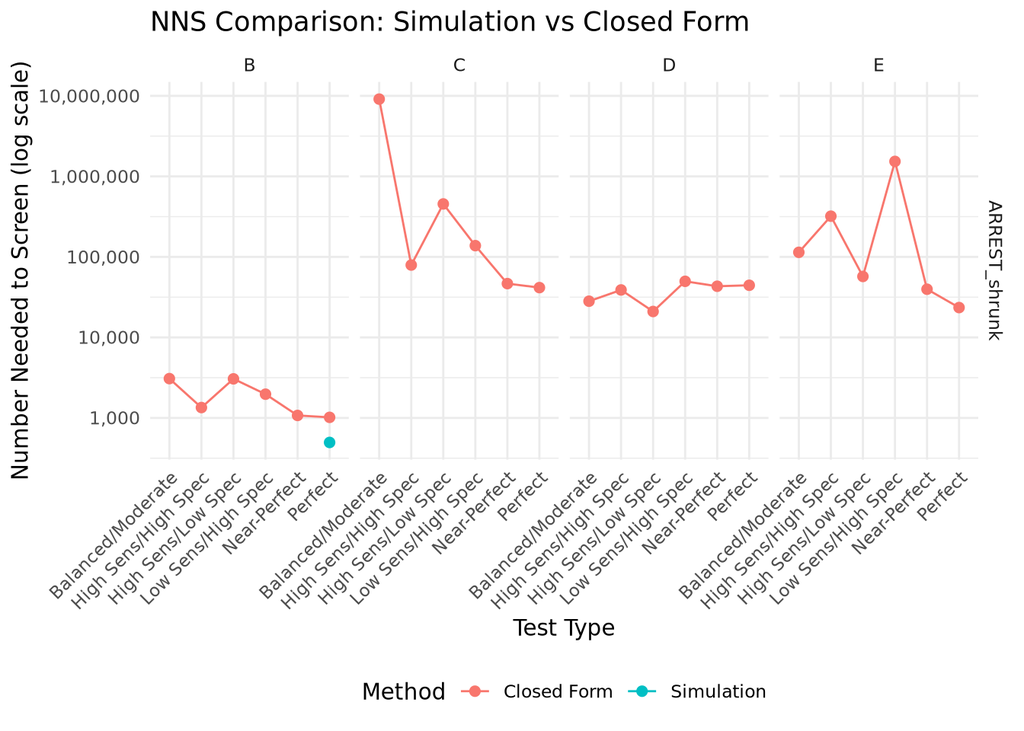

Aim 3: NNS Comparison - Simulation vs Closed Form

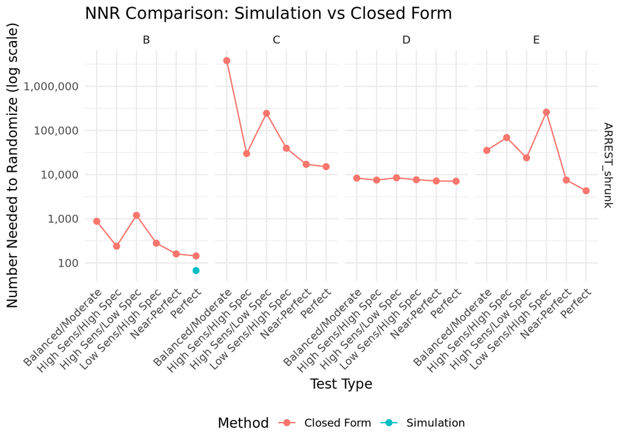

Aim 3: NNR Comparison - Simulation vs Closed Form

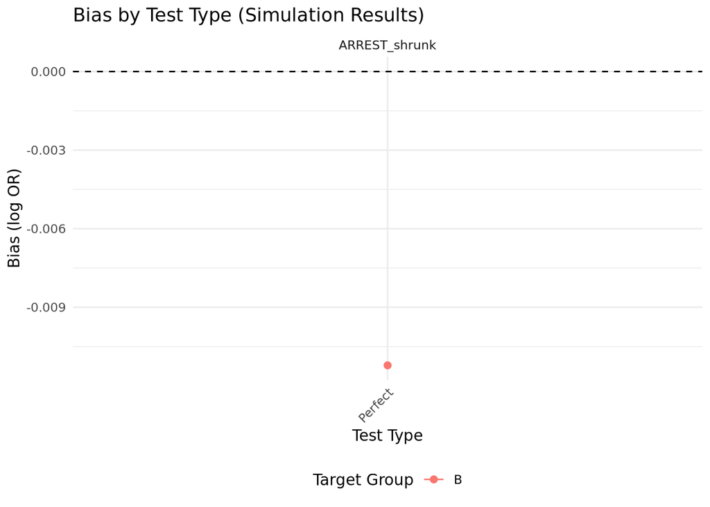

Aim 3: Bias by Test Type (Simulation Results Only)